# EDA • Exᴘʟᴏʀᴀᴛᴏʀʏ Dᴀᴛᴀ Aɴᴀʟʏsɪs

### Tʀɪᴘs: Frequency distribution by total amount (%)

```python
df['total_amount'].describe()
```

```
count    1.145622e+07
mean     1.499247e+01
std      1.237403e+01
min      0.000000e+00
25%      8.000000e+00
50%      1.130000e+01
75%      1.680000e+01
max      6.266700e+02
Name: total_amount, dtype: float64
```

```
time: 828 ms
```

```python
print(df['total_amount'].describe()[7])
print(df['total_amount'].describe()[6])
print(df['total_amount'].describe()[5])
print(df['total_amount'].describe()[4])
```

```
626.67
16.8
11.3
8.0
time: 3.24 s
```

```
<BarContainer object of 4 artists>
```

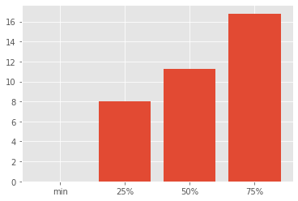

```
time: 2.08 s
```

```python
plt.bar(df['total_amount'].describe().keys()[3:7], df['total_amount'].describe()[3:7])
```

💡 **The typical amount for taxi trips in New York Mar-May 2014 has been $11.30.**

```python
orders_by_total_amount_dict = {'high amount ($50+)':        100 * sum( (df['total_amount'] <= 627) & (df['total_amount'] > 50) ) / df['total_amount'].count()}
orders_by_total_amount_dict['more thant typical ($20+)']  = 100 * sum( (df['total_amount'] <=  50) & (df['total_amount'] > 20) ) / df['total_amount'].count()
orders_by_total_amount_dict['typical ($10-$20)']          = 100 * sum( (df['total_amount'] <=  20) & (df['total_amount'] > 10) ) / df['total_amount'].count()
orders_by_total_amount_dict['low amount (less than $10)'] = 100 * sum( (df['total_amount'] <=  10) & (df['total_amount'] >  0) ) / df['total_amount'].count()
orders_by_total_amount_dict['void']                       = 100 * sum( (df['total_amount'] ==   0)                             ) / df['total_amount'].count()
orders_by_total_amount_dict
```

```
{'high amount ($50+)': 3.082307857014979,
 'more thant typical ($20+)': 14.298152942405702,
 'typical ($10-$20)': 40.39838267784813,
 'low amount (less than $10)': 42.221008131739076,
 'void': 0.0001483909921081306}
```

```
time: 10.3 s
```

```python
sum(orders_by_total_amount_dict.values())
```

```
100.0
```

```
time: 0 ns
```

```python
orders_by_total_amount = pd.DataFrame(
                      orders_by_total_amount_dict.values(),
              index = orders_by_total_amount_dict.keys(),
              columns = ['%'])
orders_by_total_amount.sort_values(by='%',ascending=False, inplace=True)
orders_by_total_amount
```

|  | % |
| --- | --- |
| low amount (less than $10) | 42.221008 |
| typical ($10-$20) | 40.398383 |
| more thant typical ($20+) | 14.298153 |
| high amount ($50+) | 3.082308 |
| void | 0.000148 |

```
time: 15 ms
```

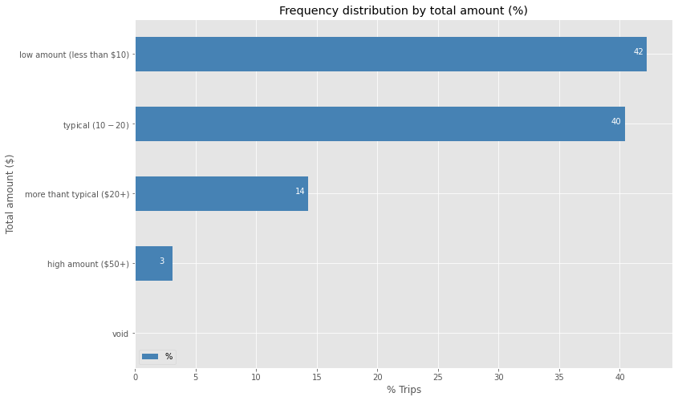

```
time: 359 ms
```

```python
## Distribution %

orders_by_total_amount.sort_values(by='%',ascending=True, inplace=True)
orders_by_total_amount.plot(kind='barh', figsize=(12, 8), color='steelblue')
plt.xlabel('% Trips')
plt.ylabel('Total amount ($)')
plt.title('Frequency distribution by total amount (%)')

for i, value in enumerate(orders_by_total_amount['%']):
    label = format(int(value))

    # place text at the end of bar (subtracting 1.1% from x, and 0 from y to make it fit within the bar)
    plt.annotate(label, xy=(value - 1.1, i - 0), color='white')

plt.show()
```

💡 **Typical amount: \$11.30.**  
💡 **82% of trips amount to up to $20.** 💡 **42% of them amount to less than \$10 .**

### Tʀɪᴘs: Frequency distribution by average speed, mph (%)

```python
df['mph'].describe()
```

```
count    1.145622e+07
mean     1.367559e+01
std      1.304318e+02
min      0.000000e+00
25%      8.300000e+00
50%      1.127610e+01
75%      1.526250e+01
max      1.263600e+05
Name: mph, dtype: float64
```

```
time: 1.09 s
```

```python
print(df['mph'].describe()[7])
print(df['mph'].describe()[6])
print(df['mph'].describe()[5])
print(df['mph'].describe()[4])
```

```
126360.0
15.2625
11.276102088167054
8.3
time: 3.22 s
```

```
<BarContainer object of 4 artists>
```

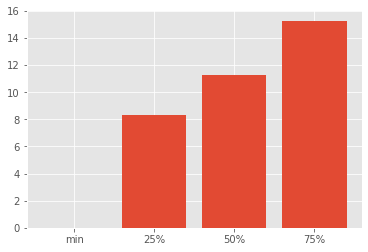

```
time: 1.77 s
```

```python
plt.bar(df['mph'].describe().keys()[3:7], df['mph'].describe()[3:7])
```

💡 **The typical speed of taxi trips in New York Mar-May 2014 has been 11.3 mph.**

```python
orders_by_mph_dict = {'high speed (30+ mph)':           100 * sum( (df['mph'] <= 126360) & (df['mph'] > 30) ) / df['mph'].count()}
orders_by_mph_dict['above typical speed (15-30 mph)'] = 100 * sum( (df['mph'] <=     30) & (df['mph'] > 15) ) / df['mph'].count()
orders_by_mph_dict['typical (low) speed (10-15 mph)'] = 100 * sum( (df['mph'] <=     15) & (df['mph'] > 10) ) / df['mph'].count()
orders_by_mph_dict['very low speed (below 10 mph)']   = 100 * sum( (df['mph'] <=     10) & (df['mph'] >  0) ) / df['mph'].count()
orders_by_mph_dict['void']                            = 100 * sum( (df['mph'] ==      0)                    ) / df['mph'].count()
orders_by_mph_dict
```

```
{'high speed (30+ mph)': 2.6470247038704997,
 'above typical speed (15-30 mph)': 23.393508208335017,
 'typical (low) speed (10-15 mph)': 34.52408957543679,
 'very low speed (below 10 mph)': 38.82141414695125,
 'void': 0.613963365406446}
```

```
time: 10.9 s
```

```python
sum(orders_by_mph_dict.values())
```

```
100.0
```

```
time: 15 ms
```

```python
orders_by_mph = pd.DataFrame(
                      orders_by_mph_dict.values(),
              index = orders_by_mph_dict.keys(),
              columns = ['%'])
orders_by_mph.sort_values(by='%',ascending=False, inplace=True)
orders_by_mph
```

|  | % |
| --- | --- |
| very low speed (below 10 mph) | 38.821414 |
| typical (low) speed (10-15 mph) | 34.524090 |
| above typical speed (15-30 mph) | 23.393508 |
| high speed (30+ mph) | 2.647025 |
| void | 0.613963 |

```
time: 125 ms
```

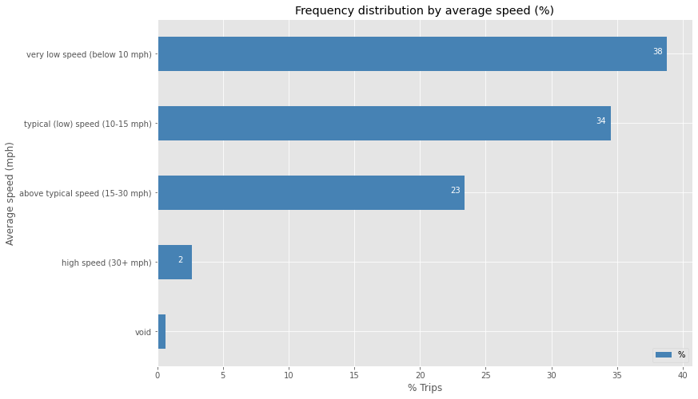

```
time: 640 ms
```

```python
## Distribution %

orders_by_mph.sort_values(by='%',ascending=True, inplace=True)
orders_by_mph.plot(kind='barh', figsize=(12, 8), color='steelblue')
plt.xlabel('% Trips')
plt.ylabel('Average speed (mph)')
plt.title('Frequency distribution by average speed (%)')

for i, value in enumerate(orders_by_mph['%']):
    label = format(int(value))

    # place text at the end of bar (subtracting 1.1% from x, and 0 from y to make it fit within the bar)
    plt.annotate(label, xy=(value - 1.1, i - 0), color='white')


plt.savefig('./img/tst.jpg')
plt.show()
```

*Fine!* ✔️✔️✔️

## Exporting results for retrieval

```python
df.to_csv('df_EDA.csv')
```

```
time: 8min 45s
```

Note: it seems, we could have rich vizes pretty efficently using the [« **lux** Python API for intelligent visual data discovery»](abc.html) library.  
Well, it's still to work here (getting advice from community).

# Next: Mᴏᴅᴇʟɪɴɢ: Time Series Analysis • Forecasting